# Avaliação Final Análise Descritiva e Probabilidade

Fabiano Antunes, Felipe Magno, Gabriela Araújo

2025-06-15

## Análise 1: Estatística Descritiva dos dados ENADE 2017

### A) Importando os dados ENADE 2017

```r
enade2017 = read_csv2("MICRODADOS_ENADE_2017.txt")
head(enade2017) #visualizar de forma resumida os dados
```

```
## # A tibble: 6 x 150
##   NU_ANO CO_IES CO_CATEGAD CO_ORGACAD CO_GRUPO CO_CURSO CO_MODALIDADE
##    <dbl>  <dbl>      <dbl>      <dbl>    <dbl>    <dbl>         <dbl>
## 1   2017      1          1      10028     5710        3             1
## 2   2017      1          1      10028     5710        3             1
## 3   2017      1          1      10028     5710        3             1
## 4   2017      1          1      10028     5710        3             1
## 5   2017      1          1      10028     5710        3             1
## 6   2017      1          1      10028     5710        3             1
## # i 143 more variables: CO_MUNIC_CURSO <dbl>, CO_UF_CURSO <dbl>,
## #   CO_REGIAO_CURSO <dbl>, NU_IDADE <dbl>, TP_SEXO <chr>, ANO_FIM_EM <dbl>,
## #   ANO_IN_GRAD <dbl>, CO_TURNO_GRADUACAO <dbl>, TP_INSCRICAO_ADM <dbl>,
## #   TP_INSCRICAO <dbl>, NU_ITEM_OFG <dbl>, NU_ITEM_OFG_Z <dbl>,
## #   NU_ITEM_OFG_X <dbl>, NU_ITEM_OFG_N <dbl>, NU_ITEM_OCE <dbl>,
## #   NU_ITEM_OCE_Z <dbl>, NU_ITEM_OCE_X <dbl>, NU_ITEM_OCE_N <dbl>,
## #   DS_VT_GAB_OFG_ORIG <chr>, DS_VT_GAB_OFG_FIN <chr>, ...
```

### B) Selecionando as variáveis indicadas

```r
microdados_enade_filtrados= enade2017 %>% dplyr::select(CO_GRUPO,
                                                       TP_SEXO,
                                                       CO_TURNO_GRADUACAO,
                                                       CO_REGIAO_CURSO,
                                                       QE_I02,
                                                       NT_OBJ_FG,
                                                       QE_I08,
                                                       QE_I23,
                                                       NT_OBJ_CE,
                                                       NT_GER
)
head(microdados_enade_filtrados) #conferindo se o filtro deu certo
```

```
## # A tibble: 6 x 10
##   CO_GRUPO TP_SEXO CO_TURNO_GRADUACAO CO_REGIAO_CURSO QE_I02 NT_OBJ_FG QE_I08
##      <dbl> <chr>                <dbl>           <dbl> <chr>      <dbl> <chr>
## 1     5710 F                        3               5 A           87.5 B
## 2     5710 F                        3               5 D           87.5 B
## 3     5710 M                        3               5 D           87.5 F
## 4     5710 M                        3               5 A           75   B
## 5     5710 M                        3               5 A           75   F
## 6     5710 M                        3               5 F           87.5 C
## # i 3 more variables: QE_I23 <chr>, NT_OBJ_CE <dbl>, NT_GER <dbl>
```

#### Classificando as variáveis

- **NT_OBJ_FG**: Nota bruta na parte objetiva da formação geral — **Variável Quantitativa Contínua**
- **CO_GRUPO**: Código da área de enquadramento do curso no Enade — **Variável Qualitativa Nominal**
- **CO_REGIAO_CURSO**: Código da região de funcionamento do curso — **Variável Qualitativa Nominal**
- **QE_I02**: Questionário de qual cor/raça — **Variável Qualitativa Nominal**
- **CO_TURNO_GRADUACAO**: Código do turno de graduação — **Variável Qualitativa Ordinal**
- **TP_SEXO**: Tipo de Sexo — **Variável Qualitativa Nominal**
- **QE_I08**: Renda familiar — **Variável Qualitativa Ordinal**
- **QE_I23**: Horas dedicadas aos estudos — **Variável Qualitativa Ordinal**
- **NT_OBJ_CE**: Nota bruta na parte objetiva da formação específica — **Variável Quantitativa Contínua**
- **NT_GER**: Nota bruta da prova — **Variável Quantitativa Contínua**

### C) Filtrando pelo Curso escolhido

Foi escolhido aleatoriamente o curso 6208 = Engenharia de Produção

```r
microdados_ti = microdados_enade_filtrados %>% filter(CO_GRUPO==6208)
head(microdados_ti)
```

```
## # A tibble: 6 x 10
##   CO_GRUPO TP_SEXO CO_TURNO_GRADUACAO CO_REGIAO_CURSO QE_I02 NT_OBJ_FG QE_I08
##      <dbl> <chr>                <dbl>           <dbl> <chr>      <dbl> <chr>
## 1     6208 M                        3               3 A           62.5 E
## 2     6208 F                        3               3 A           87.5 F
## 3     6208 F                        3               3 C           87.5 E
## 4     6208 F                        3               3 C           87.5 F
## 5     6208 M                        3               3 C           75   F
## 6     6208 F                        3               3 A           75   C
## # i 3 more variables: QE_I23 <chr>, NT_OBJ_CE <dbl>, NT_GER <dbl>
```

### D) Transformando as variáveis

```r
microdados_ti <- microdados_ti %>%
  mutate(
    raca = case_when(
      QE_I02 == "A" ~ "Branca",
      QE_I02 == "B" ~ "Preta",
      QE_I02 == "C" ~ "Amarela",
      QE_I02 == "D" ~ "Parda",
      QE_I02 == "E" ~ "Indígena",
      QE_I02 == "F" ~ "Não declarou"
    ),
    regiao = case_when(
      CO_REGIAO_CURSO == 1 ~ "Norte",
      CO_REGIAO_CURSO == 2 ~ "Nordeste",
      CO_REGIAO_CURSO == 3 ~ "Sudeste",
      CO_REGIAO_CURSO == 4 ~ "Sul",
      CO_REGIAO_CURSO == 5 ~ "Centro-Oeste"
    ),
    sexo = case_when(
      TP_SEXO == "M" ~ "Masculino",
      TP_SEXO == "F" ~ "Feminino"
    ),
    hestudos = case_when(
      QE_I23 == "A" ~ "Nenhuma, apenas assisto às aulas",
      QE_I23 == "B" ~ "De uma a três",
      QE_I23 == "C" ~ "De quatro a sete",
      QE_I23 == "D" ~ "De oito a doze",
      QE_I23 == "E" ~ "Mais de doze"
    ),
    hsalario = case_when(
      QE_I08 == "A" ~ "Até 1,5 SM (até R$ 1.405,50)",
      QE_I08 == "B" ~ "1,5 a 3 SM (R$ 1.405,51 a R$ 2.811,00)",
      QE_I08 == "C" ~ "3 a 4,5 SM (R$ 2.811,01 a R$ 4.216,50)",
      QE_I08 == "D" ~ "4,5 a 6 SM (R$ 4.216,51 a R$ 5.622,00)",
      QE_I08 == "E" ~ "6 a 10 SM (R$ 5.622,01 a R$ 9.370,00)",
      QE_I08 == "F" ~ "10 a 30 SM (R$ 9.370,01 a R$ 28.110,00)",
      QE_I08 == "G" ~ "Acima de 30 SM (mais de R$ 28.110,00)"
    ),
    hturno = case_when(
      CO_TURNO_GRADUACAO == 1 ~ "Matutino",
      CO_TURNO_GRADUACAO == 2 ~ "Vespertino",
      CO_TURNO_GRADUACAO == 3 ~ "Noturno",
      CO_TURNO_GRADUACAO == 4 ~ "Integral",
      CO_TURNO_GRADUACAO == 5 ~ "Não realizou estágio obrigatório"
    )
  )

# Visualização das novas variáveis categóricas
microdados_ti %>%
  select(raca, regiao, sexo, hestudos, hsalario, hturno) %>%
  head(10) %>%
  kbl(caption = "Exemplo das variáveis transformadas com rótulos") %>%
  kable_styling(full_width = FALSE, bootstrap_options = c("striped", "hover", "condensed", "responsive"))
```

Exemplo das variáveis transformadas com rótulos

| raca | regiao | sexo | hestudos | hsalario | hturno |
| --- | --- | --- | --- | --- | --- |
| Branca | Sudeste | Masculino | Mais de doze | 6 a 10 SM (R$ 5.622,01 a R$ 9.370,00) | Noturno |
| Branca | Sudeste | Feminino | Mais de doze | 10 a 30 SM (R$ 9.370,01 a R$ 28.110,00) | Noturno |
| Amarela | Sudeste | Feminino | De uma a três | 6 a 10 SM (R$ 5.622,01 a R$ 9.370,00) | Noturno |
| Amarela | Sudeste | Feminino | De uma a três | 10 a 30 SM (R$ 9.370,01 a R$ 28.110,00) | Noturno |
| Amarela | Sudeste | Masculino | De quatro a sete | 10 a 30 SM (R$ 9.370,01 a R$ 28.110,00) | Noturno |
| Branca | Sudeste | Feminino | De quatro a sete | 3 a 4,5 SM (R$ 2.811,01 a R$ 4.216,50) | Noturno |
| Branca | Sudeste | Masculino | De quatro a sete | 3 a 4,5 SM (R$ 2.811,01 a R$ 4.216,50) | Noturno |
| Branca | Sudeste | Masculino | De uma a três | 10 a 30 SM (R$ 9.370,01 a R$ 28.110,00) | Noturno |
| Branca | Sudeste | Feminino | De uma a três | 10 a 30 SM (R$ 9.370,01 a R$ 28.110,00) | Noturno |
| Branca | Sudeste | Feminino | De uma a três | 6 a 10 SM (R$ 5.622,01 a R$ 9.370,00) | Noturno |

### E) Estatísticas Descritivas

```r
summary(microdados_ti) #padrão para ter um overview das estatísticas do banco
```

```
##     CO_GRUPO      TP_SEXO          CO_TURNO_GRADUACAO CO_REGIAO_CURSO
##  Min.   :6208   Length:25714       Min.   :1.000      Min.   :1.000
##  1st Qu.:6208   Class :character   1st Qu.:3.000      1st Qu.:3.000
##  Median :6208   Mode  :character   Median :4.000      Median :3.000
##  Mean   :6208                      Mean   :3.574      Mean   :3.032
##  3rd Qu.:6208                      3rd Qu.:4.000      3rd Qu.:3.000
##  Max.   :6208                      Max.   :4.000      Max.   :5.000
##                                    NA's   :162
##     QE_I02            NT_OBJ_FG        QE_I08             QE_I23
##  Length:25714       Min.   :  0.0   Length:25714       Length:25714
##  Class :character   1st Qu.: 37.5   Class :character   Class :character
##  Mode  :character   Median : 50.0   Mode  :character   Mode  :character
##                     Mean   : 53.4
##                     3rd Qu.: 62.5
##                     Max.   :100.0
##                     NA's   :3262
##    NT_OBJ_CE          NT_GER          raca              regiao
##  Min.   :  0.00   Min.   : 0.00   Length:25714       Length:25714
##  1st Qu.: 31.80   1st Qu.:32.70   Class :character   Class :character
##  Median : 40.90   Median :40.90   Mode  :character   Mode  :character
##  Mean   : 41.68   Mean   :41.69
##  3rd Qu.: 50.00   3rd Qu.:50.00
##  Max.   :100.00   Max.   :88.50
##  NA's   :3262     NA's   :3262
##      sexo             hestudos           hsalario            hturno
##  Length:25714       Length:25714       Length:25714       Length:25714
##  Class :character   Class :character   Class :character   Class :character
##  Mode  :character   Mode  :character   Mode  :character   Mode  :character
##
##
##
##
```

```r
skim(microdados_ti) #calcula estatísticas básicas ao mesmo tempo que mostra nº de NAs,
```

Data summary

| Name | microdados_ti |
| --- | --- |
| Number of rows | 25714 |
| Number of columns | 16 |
| _______________________ |  |
| Column type frequency: |  |
| character | 10 |
| numeric | 6 |
| ________________________ |  |
| Group variables | None |

**Variable type: character**

| skim_variable | n_missing | complete_rate | min | max | empty | n_unique | whitespace |
| --- | --- | --- | --- | --- | --- | --- | --- |
| TP_SEXO | 0 | 1.00 | 1 | 1 | 0 | 2 | 0 |
| QE_I02 | 2423 | 0.91 | 1 | 1 | 0 | 6 | 0 |
| QE_I08 | 2423 | 0.91 | 1 | 1 | 0 | 7 | 0 |
| QE_I23 | 2423 | 0.91 | 1 | 1 | 0 | 5 | 0 |
| raca | 2423 | 0.91 | 5 | 12 | 0 | 6 | 0 |
| regiao | 0 | 1.00 | 3 | 12 | 0 | 5 | 0 |
| sexo | 0 | 1.00 | 8 | 9 | 0 | 2 | 0 |
| hestudos | 2423 | 0.91 | 12 | 32 | 0 | 5 | 0 |
| hsalario | 2423 | 0.91 | 28 | 39 | 0 | 7 | 0 |
| hturno | 162 | 0.99 | 7 | 10 | 0 | 4 | 0 |

**Variable type: numeric**

| skim_variable | n_missing | complete_rate | mean | sd | p0 | p25 | p50 | p75 | p100 | hist |
| --- | --- | --- | --- | --- | --- | --- | --- | --- | --- | --- |
| CO_GRUPO | 0 | 1.00 | 6208.00 | 0.00 | 6208 | 6208.0 | 6208.0 | 6208.0 | 6208.0 | ▁▁▇▁▁ |
| CO_TURNO_GRADUACAO | 162 | 0.99 | 3.57 | 0.86 | 1 | 3.0 | 4.0 | 4.0 | 4.0 | ▁▁▁▂▇ |
| CO_REGIAO_CURSO | 0 | 1.00 | 3.03 | 0.73 | 1 | 3.0 | 3.0 | 3.0 | 5.0 | ▁▂▇▂▁ |
| NT_OBJ_FG | 3262 | 0.87 | 53.40 | 21.24 | 0 | 37.5 | 50.0 | 62.5 | 100.0 | ▁▆▅▇▂ |
| NT_OBJ_CE | 3262 | 0.87 | 41.68 | 15.63 | 0 | 31.8 | 40.9 | 50.0 | 100.0 | ▂▇▇▂▁ |
| NT_GER | 3262 | 0.87 | 41.69 | 12.73 | 0 | 32.7 | 40.9 | 50.0 | 88.5 | ▁▅▇▃▁ |

O resumo mostra que o dataset tem 25.714 linhas e 16 colunas, com 10 variáveis categóricas e 6 numéricas. Algumas variáveis apresentam até 13% de dados ausentes, especialmente nas notas e características socioeconômicas. Os histogramas indicam que as notas têm distribuição assimétrica, com concentração em torno da média, enquanto CO_TURNO_GRADUACAO se concentra nos valores mais altos.

Como mostrado na tabela anterior, apenas as variáveis Sexo e Região não possuem NA’s. Então é necessário removê-los.

```r
#Removendo  Na
microdados_ti_sem_NA = microdados_ti %>% na.omit()

#Conferindo se NA's foram removidos
resumo_teste_variaveis= microdados_ti_sem_NA %>%
  select(everything()) %>%
  summarise_all(list(~sum(is.na(.))))
 resumo_teste_variaveis
```

```
## # A tibble: 1 x 16
##   CO_GRUPO TP_SEXO CO_TURNO_GRADUACAO CO_REGIAO_CURSO QE_I02 NT_OBJ_FG QE_I08
##      <int>   <int>              <int>           <int>  <int>     <int>  <int>
## 1        0       0                  0               0      0         0      0
## # i 9 more variables: QE_I23 <int>, NT_OBJ_CE <int>, NT_GER <int>, raca <int>,
## #   regiao <int>, sexo <int>, hestudos <int>, hsalario <int>, hturno <int>
```

### F) Análise do comportamento das notas (NT_GER) de acordo com o Turno

Para essa análise vamos partir das perguntas: 1. Há indícios de que estudantes de algum dos turnos apresentam desempenho superior aos dos demais? 2. E esse padrão se mantém independentemente da região, ou o comportamento varia conforme a localidade?

#### Primeira análise: apenas notas e turnos

```r
# Resumo estatístico com assimetria e curtose
 dados_nt_hturno <- microdados_ti_sem_NA %>%
  select(NT_GER, hturno) %>%
  group_by(hturno) %>%
  summarise(
    quantidade = n(),
    media = mean(NT_GER),
    mediana = median(NT_GER),
    cv = sd(NT_GER) / media * 100,
    amplitude_interquartil = IQR(NT_GER),
    assimetria = skewness(NT_GER),
    curtose = kurtosis(NT_GER)
  ) %>%
  arrange(desc(cv))

print( dados_nt_hturno)
```

```
## # A tibble: 4 x 8
##   hturno     quantidade media mediana    cv amplitude_interquartil assimetria
##   <chr>           <int> <dbl>   <dbl> <dbl>                  <dbl>      <dbl>
## 1 Matutino         1698  42.6    41.7  31.9                   19      0.227
## 2 Integral        16152  40.0    39.4  29.7                   16      0.276
## 3 Vespertino        379  44.6    44.3  28.0                   18.6    0.182
## 4 Noturno          3863  48.5    48.5  27.7                   18.8    0.00240
## # i 1 more variable: curtose <dbl>
```

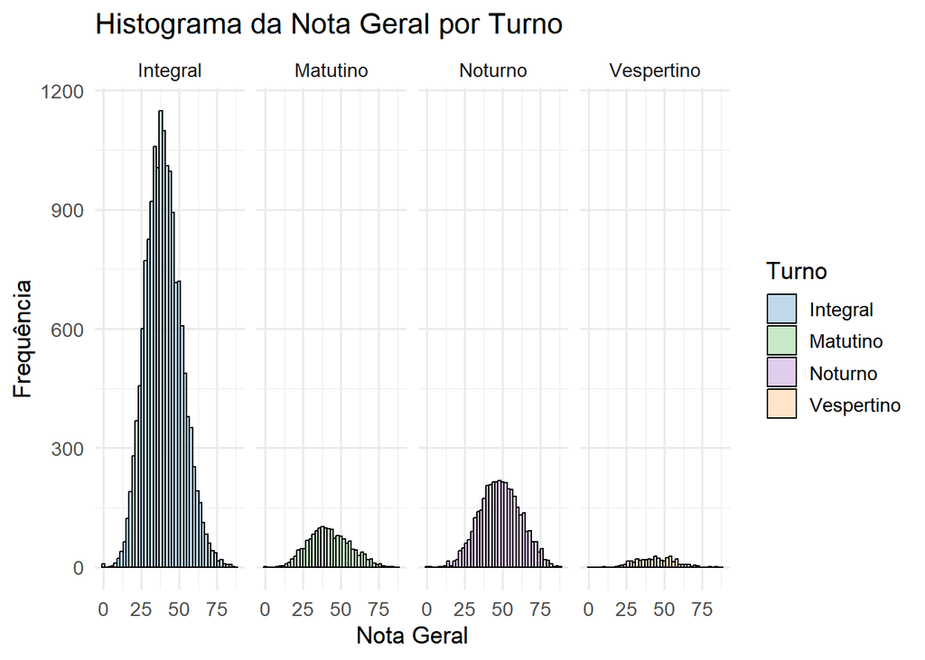

```r
# Histograma das notas gerais por turno do curso
ggplot(microdados_ti_sem_NA, aes(x = NT_GER, fill = hturno)) +
  geom_histogram(binwidth = 2, color = "black", alpha = 0.7, position = "identity") +
  ggtitle("Histograma da Nota Geral por Turno") +
  xlab("Nota Geral") +
  ylab("Frequência") +
  facet_grid(~ hturno) +
  theme_minimal(base_size = 13) +
  scale_fill_manual(
    values = c(
    "Integral" = "#a6c8e0",
    "Matutino" = "#b2dcb2",
    "Vespertino" = "#fdd9b5",
    "Noturno" = "#d2b8e2"
    ),
    name = "Turno"
  )
```

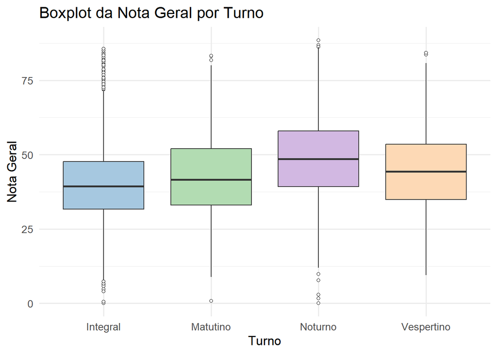

```r
# Boxplot NT_GER por turno
ggplot(microdados_ti_sem_NA, aes(x = hturno, y = NT_GER, fill = hturno)) +
  geom_boxplot(outlier.color = "black", outlier.shape = 21, outlier.fill = "white") +
  labs(title = "Boxplot da Nota Geral por Turno",
       x = "Turno",
       y = "Nota Geral") +
  theme_minimal(base_size = 13) +
  theme(legend.position = "none") +
  scale_fill_manual(
    values = c(
    "Integral" = "#a6c8e0",
    "Matutino" = "#b2dcb2",
    "Vespertino" = "#fdd9b5",
    "Noturno" = "#d2b8e2"
    )
  )
```

Os dados indicam que os alunos do turno Noturno apresentam o melhor desempenho médio e a menor variabilidade nas notas, com distribuição quase simétrica. O turno Integral, embora mais numeroso, concentra as menores médias e maior assimetria. Matutino e Vespertino têm desempenhos intermediários, sendo o Matutino o mais disperso. Essas diferenças sugerem que fatores externos, como perfil dos estudantes ou estrutura dos cursos, podem influenciar o desempenho conforme o turno.

#### Segunda análise: adicionando região na análise de nota e turno

```r
# Função para moda (caso necessário em análises futuras)
Mode <- function(x) {
  ux <- unique(x)
  ux[which.max(tabulate(match(x, ux)))]
}

# Resumo estatístico com assimetria e curtose, agora por raca
dados_hturno_regiao <- microdados_ti_sem_NA %>%
  select(regiao, NT_GER, hturno) %>%
  group_by(regiao, hturno) %>%
  summarise(
    quantidade = n(),
    media = mean(NT_GER, na.rm = TRUE),
    mediana = median(NT_GER, na.rm = TRUE),
    cv = sd(NT_GER, na.rm = TRUE) / media * 100,
    amplitude_interquartil = IQR(NT_GER, na.rm = TRUE),
    assimetria = skewness(NT_GER, na.rm = TRUE),
    curtose = kurtosis(NT_GER, na.rm = TRUE)
  ) %>%
  arrange(desc(cv))
# Visualizar tabela (opcional)
print(dados_hturno_regiao)
```

```
## # A tibble: 20 x 9
## # Groups:   regiao [5]
##    regiao       hturno     quantidade media mediana    cv amplitude_interquartil
##    <chr>        <chr>           <int> <dbl>   <dbl> <dbl>                  <dbl>
##  1 Centro-Oeste Vespertino         11  35.1    34    47.0                   15.7
##  2 Sudeste      Matutino         1191  43.0    42.1  33.2                   20.6
##  3 Norte        Matutino           37  38.8    40.3  31.1                   21.3
##  4 Centro-Oeste Integral          549  38.7    37.7  30.8                   16.4
##  5 Nordeste     Noturno           544  45.6    45.5  30.2                   19.6
##  6 Norte        Integral          441  37.6    37.1  30.1                   15.1
##  7 Sudeste      Integral        11031  39.8    39.2  30.0                   16
##  8 Nordeste     Integral         1723  38.6    38.1  29.9                   15.4
##  9 Sul          Matutino           46  42.7    41.2  28.8                   19.6
## 10 Nordeste     Matutino          377  41.3    40.7  28.5                   15.9
## 11 Centro-Oeste Noturno           266  45.8    45.8  27.9                   18.5
## 12 Sul          Vespertino         18  43.6    43.3  27.7                   16.1
## 13 Sul          Integral         2408  42.5    42.1  27.2                   15.6
## 14 Sudeste      Noturno          2308  49.4    49.3  27.2                   18.8
## 15 Norte        Vespertino         34  34.9    34.4  27.2                   11.1
## 16 Sudeste      Vespertino        126  44.6    44.7  26.5                   17.0
## 17 Nordeste     Vespertino        190  46.9    47.7  25.9                   16.9
## 18 Sul          Noturno           656  50.0    49.8  25.5                   17.7
## 19 Centro-Oeste Matutino           47  46.0    45.9  23.8                   17.6
## 20 Norte        Noturno            89  39.1    38.6  23.2                   12.5
## # i 2 more variables: assimetria <dbl>, curtose <dbl>
```

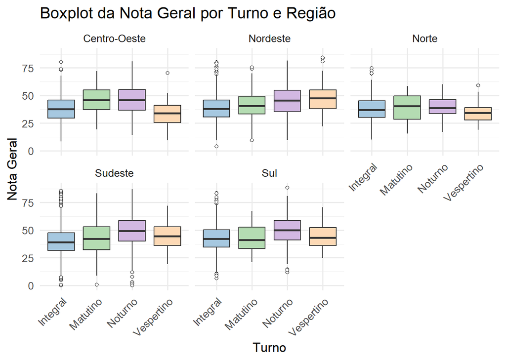

```r
# Gráfico 1: Boxplot NT_GER por turno e região
ggplot(microdados_ti_sem_NA, aes(x = hturno, y = NT_GER, fill = hturno)) +
  geom_boxplot(outlier.color = "black", outlier.shape = 21, outlier.fill = "white") +
  facet_wrap(~ regiao) +
  labs(
    title = "Boxplot da Nota Geral por Turno e Região",
    x = "Turno",
    y = "Nota Geral"
  ) +
  theme_minimal(base_size = 13) +
  theme(
    legend.position = "none",
    axis.text.x = element_text(angle = 45, hjust = 1)  # rotaciona os rótulos do eixo x
  ) +
  scale_fill_manual(
    values = c(
      "Integral" = "#a6c8e0",
      "Matutino" = "#b4dcb2",
      "Vespertino" = "#fdd9b5",
      "Noturno" = "#d2b8e2"
    )
  )
```

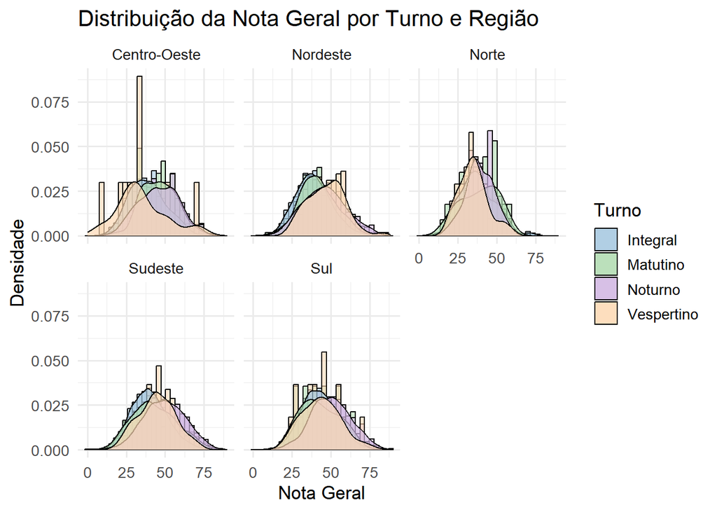

```r
# Gráfico 2: Histograma com densidade
ggplot(microdados_ti_sem_NA, aes(x = NT_GER, fill = hturno)) +
  geom_histogram(aes(y = ..density..), bins = 30, alpha = 0.6, position = "identity", color = "black") +
  geom_density(alpha = 0.7, color = "black") +
  facet_wrap(~ regiao) +
  labs(title = "Distribuição da Nota Geral por Turno e Região",
       x = "Nota Geral",
       y = "Densidade") +
  theme_minimal(base_size = 13) +
  scale_fill_manual(
    values = c(
    "Integral" = "#a6c8e0",
    "Matutino" = "#b2dcb2",
    "Vespertino" = "#fdd9b5",
    "Noturno" = "#d2b8e2"
    ),
    name = "Turno"
  )
```

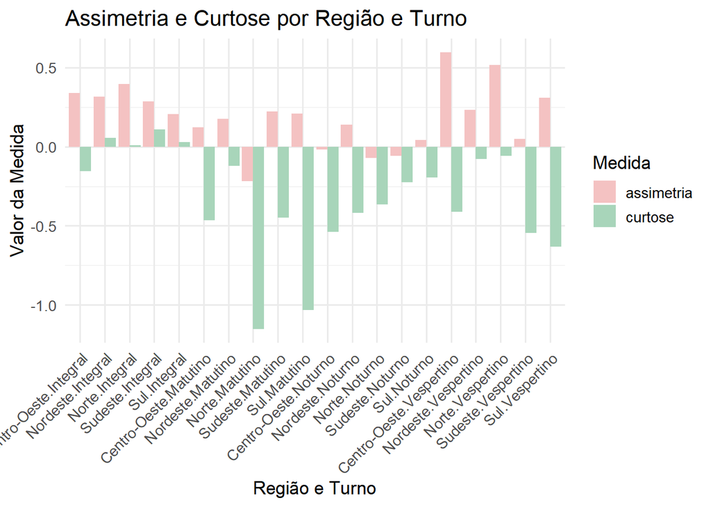

```r
# Gráfico 3: Barras com assimetria e curtose por grupo
# Transforma os dados para formato longo para gráfico de barras
dados_longos <- dados_hturno_regiao %>%
  select(regiao, hturno, assimetria, curtose) %>%
  tidyr::pivot_longer(cols = c("assimetria", "curtose"), names_to = "medida", values_to = "valor")
ggplot(dados_longos, aes(x = interaction(regiao, hturno), y = valor, fill = medida)) +
  geom_bar(stat = "identity", position = "dodge") +
  labs(title = "Assimetria e Curtose por Região e Turno",
       x = "Região e Turno",
       y = "Valor da Medida",
       fill = "Medida") +
  theme_minimal(base_size = 13) +
  theme(axis.text.x = element_text(angle = 45, hjust = 1)) +
  scale_fill_manual(
    values = c(
      "assimetria" = "#F4C2C2",
      "curtose" = "#A8D5BA"
    )
  )
```

Os dados analisados indicam que há, sim, diferenças de desempenho entre os turnos, mas essas diferenças não são uniformes entre as regiões. Embora o turno noturno apresente médias superiores em alguns contextos, o desempenho dos estudantes varia significativamente de acordo com a localização geográfica. O turno matutino, que à primeira vista poderia ser associado a um melhor desempenho, não se destacou de forma consistente, e o turno integral, apesar de contar com o maior número de estudantes, apresentou médias inferiores em diversas regiões.

Portanto, não é possível afirmar que um turno seja universalmente superior aos demais. O padrão de desempenho está claramente relacionado a características regionais e contextuais.

Além disso, o gráfico de assimetria e curtose reforça essa conclusão ao mostrar que a forma das distribuições das notas varia substancialmente entre turnos e regiões. Enquanto alguns contextos apresentam distribuições mais simétricas ou levemente enviesadas, outros revelam maior assimetria ou curtose negativa. Isso evidencia a ausência de um padrão único de desempenho e destaca a importância de considerar as especificidades regionais e do turno ao analisar os resultados acadêmicos.